# Section 6 — Direct Simulation and Importance Sampling

STA5001 R Computational Companion

STA5001 Bayesian & Computational Statistics

Open `section-06.Rmd` in RStudio and choose **Knit**. The examples use BayesComp for the Eight Schools data, Gaussian calculations, and lecture figures. From the repository root, run `R CMD INSTALL BayesComp` in a terminal to install the package from this checkout before knitting.

The methods answer different computational questions. Inversion turns uniform draws into posterior draws when a CDF is available. Rejection uses an envelope to retain posterior draws. Importance sampling keeps the proposals and changes how much each one contributes to a posterior summary.

# Section 6.1 — Inverse CDF Method

## Percentiles and continuous inversion

**Concept.** A draw from a continuous CDF $F$ has a uniform percentile $F(X)$. Inversion starts with a uniform percentile and returns a draw on the parameter scale.

**Example.** Return to the $\operatorname{Beta}(9,21)$ posterior from Section 2.1. Compare the widths of the intervals between the 20th and 30th percentiles and between the 80th and 90th percentiles.

Use `qbeta()` for the interval endpoints and `pbeta()` to confirm their probability. Then pass independent uniforms to the same quantile function and compare the resulting sample mean with $9/30$.

```r
levels <- rbind(lower = c(.2, .3), upper = c(.8, .9))
endpoints <- qbeta(levels, shape1 = 9, shape2 = 21)
knitr::kable(data.frame(left = endpoints[, 1], right = endpoints[, 2],
                        width = endpoints[, 2] - endpoints[, 1],
                        probability = pbeta(endpoints[, 2], 9, 21) -
                          pbeta(endpoints[, 1], 9, 21)), digits = 4)
```

|  | left | right | width | probability |
| --- | --- | --- | --- | --- |
| lower | 0.2285 | 0.2529 | 0.0243 | 0.1 |
| upper | 0.3690 | 0.4092 | 0.0402 | 0.1 |

```r
set.seed(61027)
u_beta <- runif(10000)
theta_beta <- qbeta(u_beta, 9, 21)
beta_mcse <- sd(theta_beta) / sqrt(length(theta_beta))
stopifnot(max(abs(pbeta(theta_beta, 9, 21) - u_beta)) < 1e-12,
          abs(mean(theta_beta) - .3) < 5 * beta_mcse)
c(simulated_mean = mean(theta_beta), exact_mean = .3, MCSE = beta_mcse)
```

```
## simulated_mean     exact_mean           MCSE
##   0.3001890279   0.3000000000   0.0008204404
```

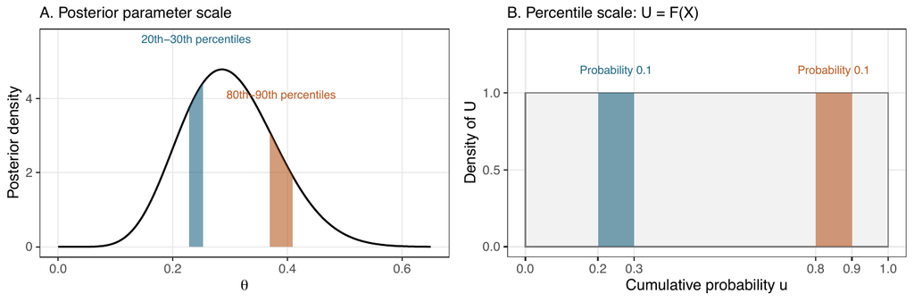

Lecture notes, Section 6.1. The shaded regions have different widths on the parameter scale and equal widths on the percentile scale.

## Inversion at CDF jumps

**Concept.** At a jump, the quantile is the first value where the CDF reaches or exceeds the requested probability.

**Example.** Let $X$ take values $0,1,3$ with masses $0.2,0.5,0.3$. In particular, $u=0.6$ belongs to the jump at one.

Accumulate the probability masses in support order. For each input, find the first eligible index. Checking the input $u=0.2$ makes the endpoint convention explicit.

```r
support <- c(0, 1, 3)
masses <- c(.2, .5, .3)
cumulative_mass <- cumsum(masses)
discrete_quantile <- function(u) {
  vapply(u, function(p) support[which(cumulative_mass >= p)[1]], numeric(1))
}

stopifnot(identical(discrete_quantile(c(.2, .6, .9)), support))
knitr::kable(data.frame(u = c(.2, .6, .9),
                        quantile = discrete_quantile(c(.2, .6, .9))))
```

| u | quantile |
| --- | --- |
| 0.2 | 0 |
| 0.6 | 1 |
| 0.9 | 3 |

| support | exact | simulated |
| --- | --- | --- |
| 0 | 0.2 | 0.1983 |
| 1 | 0.5 | 0.5092 |
| 3 | 0.3 | 0.2925 |

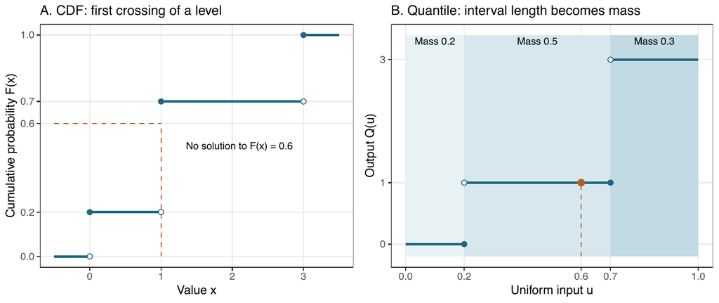

Lecture notes, Section 6.1. The first crossing for a uniform input of 0.6 is at one.

```r
set.seed(61028)
discrete_draws <- discrete_quantile(runif(10000))
simulated_mass <- tabulate(match(discrete_draws, support),
                            nbins = length(support)) / length(discrete_draws)
knitr::kable(data.frame(support, exact = masses, simulated = simulated_mass),
             digits = 4)
```

## Numerical inversion for Eight Schools

**Concept.** A numerical posterior CDF can have truncation error from the finite integration range and discretization error from the grid. Increasing the number of draws reduces simulation error for that computed CDF.

**Example.** For Rubin’s Eight Schools, estimate $\Pr(\tau>10\mid\mathbf y)$, where $\tau$ is the between-school standard deviation in SAT-Verbal points. The observations are effect estimates with known sampling variances $s_j^2$. Use the Section 3 Gaussian model with $\eta\sim N(0,400)$ and $\tau^2\sim\operatorname{IG}(3,200)$.

Use the package’s integrated likelihood, adding the prior on $\tau$. The expression for the prior includes the Jacobian $2\tau$ from variance to standard deviation. For an independent check on the trapezoidal CDF, integrate adaptively in $z=\log\tau$. The second Jacobian adds $z$ to the log density.

```r
library(BayesComp)
data("eight_schools", package = "BayesComp")
knitr::kable(eight_schools, col.names = c("School", "Estimated effect", "SE"))
```

| School | Estimated effect | SE |
| --- | --- | --- |
| A | 28 | 15 |
| B | 8 | 10 |
| C | -3 | 16 |
| D | 7 | 11 |
| E | -1 | 9 |
| F | 1 | 11 |
| G | 18 | 10 |
| H | 12 | 18 |

```r
school_y <- setNames(eight_schools$effect, eight_schools$school)
school_s2 <- setNames(eight_schools$se^2, eight_schools$school)

log_scale_prior <- function(tau, b = 200) {
  result <- rep(-Inf, length(tau))
  positive <- tau > 0
  t <- tau[positive]
  result[positive] <- log(2) + 3 * log(b) - lgamma(3) -
    7 * log(t) - b / t^2
  result
}

log_scale_kernel <- function(z, b = 200) {
  # Outside this range the kernel is negligible in double precision.
  result <- rep(-Inf, length(z))
  inside <- is.finite(z) & abs(z) < 350
  if (any(inside)) {
    tau <- exp(z[inside])
    result[inside] <- school_means_log_likelihood(tau, school_y, school_s2,
                                                   m0 = 0, v0 = 400) +
      log_scale_prior(tau, b) + z[inside]
  }
  result
}

mode_fit <- optimize(log_scale_kernel, c(-4, 8), maximum = TRUE, tol = 1e-10)
scale_integral <- function(h, lower = -Inf, upper = Inf, b = 200) {
  integrand <- function(z) {
    kernel <- log_scale_kernel(z, b)
    active <- is.finite(kernel)
    value <- numeric(length(z))
    if (any(active)) {
      value[active] <- exp(kernel[active] - mode_fit$objective) * h(exp(z[active]))
    }
    value
  }
  integrate(integrand, lower, upper, rel.tol = 1e-9)$value
}
ones <- function(tau) rep(1, length(tau))
scale_norm <- scale_integral(ones)
tail_reference <- scale_integral(ones, lower = log(10)) / scale_norm
stopifnot(abs(tail_reference - .169870) < 5e-7)
c(tail_reference = tail_reference)
```

```
## tail_reference
##      0.1698696
```

For each $(T,h)$ in the notes, the package accumulates trapezoidal masses and normalizes them on $[0,T]$. Linearly interpolate at 10. Compare the result with quadrature before sampling, so the error column isolates the numerical approximation.

```r
settings <- data.frame(T = c(20, 80, 80, 80), h = c(2, 2, .5, .1))
school_grids <- Map(function(T, h) {
  school_means_grid(school_y, school_s2, 0, 400, log_scale_prior,
                    upper = T, n_grid = as.integer(round(T / h)) + 1L)
}, settings$T, settings$h)

computed_cdf <- function(grid, tau) {
  approx(grid$tau, grid$cdf, xout = tau, rule = 2)$y
}

implied_tail <- vapply(school_grids, function(g) 1 - computed_cdf(g, 10),
                        numeric(1))
omitted_tail <- vapply(settings$T, function(T) {
  scale_integral(ones, lower = log(T)) / scale_norm
}, numeric(1))
knitr::kable(cbind(settings, implied_tail,
                   CDF_error = implied_tail - tail_reference, omitted_tail),
             digits = 7)
```

| T | h | implied_tail | CDF_error | omitted_tail |
| --- | --- | --- | --- | --- |
| 20 | 2.0 | 0.1828170 | 0.0129474 | 0.0008261 |
| 80 | 2.0 | 0.1835442 | 0.0136747 | 0.0000000 |
| 80 | 0.5 | 0.1707669 | 0.0008973 | 0.0000000 |
| 80 | 0.1 | 0.1699055 | 0.0000359 | 0.0000000 |

To invert, locate the two grid nodes bracketing each uniform percentile and interpolate on that segment. This is the direct solution of the piecewise-linear CDF. Bisection gives the same answer when the CDF is supplied only as a callable function. Its upper endpoint always has CDF at least as large as the requested percentile.

```r
fine <- school_grids[[4]]
set.seed(61029)
u_scale <- runif(10000)
left <- findInterval(u_scale, fine$cdf, left.open = TRUE)
right <- left + 1L
fraction <- (u_scale - fine$cdf[left]) / (fine$cdf[right] - fine$cdf[left])
tau_draw <- fine$tau[left] + fraction * (fine$tau[right] - fine$tau[left])

bisect_quantile <- function(p, cdf, lower, upper, tol = 1e-6) {
  stopifnot(cdf(lower) < p, cdf(upper) >= p)
  while (upper - lower > tol) {
    midpoint <- (lower + upper) / 2
    if (cdf(midpoint) < p) lower <- midpoint else upper <- midpoint
  }
  upper
}
fine_cdf <- function(tau) computed_cdf(fine, tau)
first_bisected <- bisect_quantile(u_scale[1], fine_cdf, 0, 80)
stopifnot(abs(first_bisected - tau_draw[1]) <= 1e-6)

tail_draw <- tau_draw > 10
tail_mcse <- sd(tail_draw) / sqrt(length(tail_draw))
stopifnot(max(abs(computed_cdf(fine, tau_draw) - u_scale)) < 1e-12,
          abs(mean(tail_draw) - implied_tail[4]) < 5 * tail_mcse)
c(quadrature = tail_reference, grid = implied_tail[4],
  simulated = mean(tail_draw), MCSE = tail_mcse)
```

```
##  quadrature        grid   simulated        MCSE
## 0.169869589 0.169905476 0.169400000 0.003751236
```

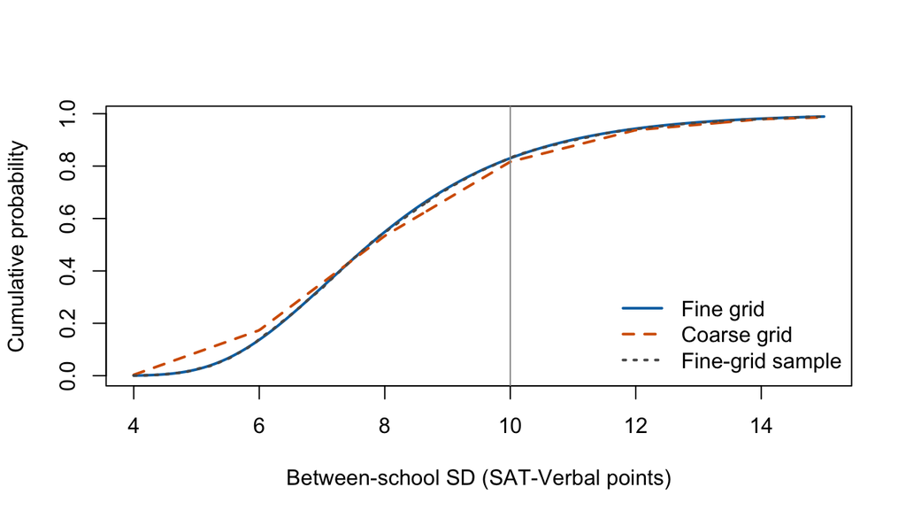

The coarse and fine grids differ near the threshold. The empirical CDF fluctuates around the fine computed CDF because the draw count is finite.

```r
window <- seq(4, 15, length.out = 300)
plot(window, computed_cdf(fine, window), type = "l", lwd = 2,
     col = "#0072B2", xlab = "Between-school SD (SAT-Verbal points)",
     ylab = "Cumulative probability")
lines(window, computed_cdf(school_grids[[2]], window), col = "#D55E00",
      lty = 2, lwd = 2)
lines(window, ecdf(tau_draw)(window), col = "grey35", lty = 3, lwd = 2)
abline(v = 10, col = "grey60")
legend("bottomright", c("Fine grid", "Coarse grid", "Fine-grid sample"),
       lty = 1:3, lwd = 2, col = c("#0072B2", "#D55E00", "grey35"), bty = "n")
```

The fine-grid discrepancy is small relative to the MCSE here. Doubling the draw count would leave the grid discrepancy in place. Section 6.3 shows how to attach dependent school effects to each draw of the scale.

# Section 6.2 — Rejection Sampling

## A global bound for the daily-count posterior

**Concept.** When a normalized proposal $q$ covers the posterior kernel $k$ and $k/q\le B$ everywhere, retaining a proposal with probability $k/(Bq)$ gives a posterior draw.

**Example.** The 12 counts from Section 5 are $(0,0,1,1,1,2,2,2,3,4,5,7)$. Conditional on $H_1$, the counts have a negative-binomial distribution with size 2 and daily mean $\lambda$. Use the $\operatorname{Gamma}(2,1)$ prior as the proposal. The ratio $k/q$ is the likelihood kernel, which has its global maximum at $7/3$ by the derivative calculation in the notes.

Generate prior draws in batches. For each candidate compare $\log U$ with the log likelihood minus its maximum. Stop the retained sequence at acceptance 10,000 and count proposals through that acceptance. The final batch is generated for vectorization, so the logical stopping count can be smaller than the number actually generated in R.

```r
counts <- c(0, 0, 1, 1, 1, 2, 2, 2, 3, 4, 5, 7)
total <- sum(counts)
size <- 2
log_count_likelihood <- function(lambda) {
  total * log(lambda) - (total + length(counts) * size) * log(lambda + size)
}
lambda_mode <- mean(counts)
log_bound <- log_count_likelihood(lambda_mode)

set.seed(62027)
n_accept <- 10000L
retained <- numeric(n_accept)
filled <- proposed <- 0L
while (filled < n_accept) {
  candidate <- rgamma(10000L, shape = 2, rate = 1)
  log_acceptance <- log_count_likelihood(candidate) - log_bound
  stopifnot(all(log_acceptance <= 1e-12))
  accepted <- which(log(runif(length(candidate))) <= log_acceptance)
  take <- min(length(accepted), n_accept - filled)
  kept <- head(accepted, take)
  retained[filled + seq_len(take)] <- candidate[kept]
  filled <- filled + take
  proposed <- proposed + if (filled == n_accept) tail(kept, 1) else length(candidate)
}
c(accepted = n_accept, proposals_through_last_acceptance = proposed)
```

```
##                          accepted proposals_through_last_acceptance
##                             10000                             29214
```

Average three functions of the retained rates. For weekly capacity, use the conditional probability from a negative-binomial distribution with size 14 and mean $7\lambda$. The table compares those averages with adaptive quadrature of the posterior and reports an iid MCSE for each target. Quadrature also gives the reference acceptance rate.

```r
count_proposal <- function(lambda) dgamma(lambda, 2, rate = 1)
accept_prob <- function(lambda) exp(log_count_likelihood(lambda) - log_bound)
accepted_kernel <- function(lambda) count_proposal(lambda) * accept_prob(lambda)
quad <- function(f, lower = 0, upper = Inf) {
  integrate(f, lower, upper, rel.tol = 1e-10)$value
}
acceptance <- quad(accepted_kernel)
count_posterior <- function(lambda) accepted_kernel(lambda) / acceptance
weekly_risk <- function(lambda) {
  pnbinom(25, size = 14, mu = 7 * lambda, lower.tail = FALSE)
}

count_reference <- c(quad(function(x) x * count_posterior(x)),
                     quad(count_posterior, lower = 3),
                     quad(function(x) weekly_risk(x) * count_posterior(x)))
h_count <- cbind(retained, retained > 3, weekly_risk(retained))
count_estimate <- colMeans(h_count)
count_mcse <- apply(h_count, 2, sd) / sqrt(n_accept)
stopifnot(abs(acceptance - .341171767725) < 1e-9,
          all(abs(count_estimate - count_reference) < 5 * count_mcse))
knitr::kable(data.frame(summary = c("Mean daily rate", "Pr(rate > 3)",
                                     "Pr(weekly count > 25)"),
                        quadrature = count_reference, estimate = count_estimate,
                        MCSE = count_mcse), digits = 4)
```

| summary | quadrature | estimate | MCSE |
| --- | --- | --- | --- |
| Mean daily rate | 2.3518 | 2.3544 | 0.0061 |
| Pr(rate > 3) | 0.1410 | 0.1425 | 0.0035 |
| Pr(weekly count > 25) | 0.1146 | 0.1145 | 0.0013 |

```
##         observed_acceptance       quadrature_acceptance
##                   0.3423016                   0.3411718
## expected_proposals_per_draw
##                   2.9310749
```

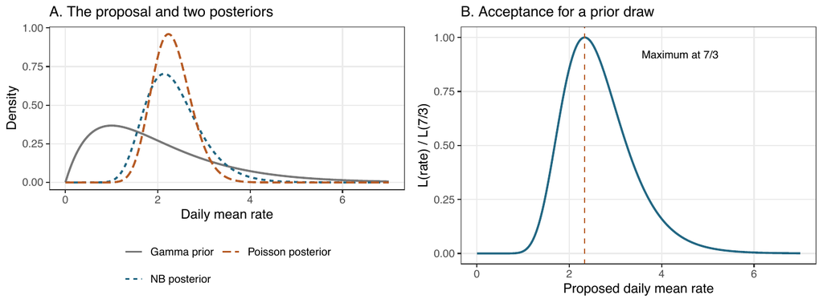

Lecture notes, Section 6.2. The prior supplies the proposals. The likelihood ratio is largest at 7/3.

```r
c(observed_acceptance = n_accept / proposed, quadrature_acceptance = acceptance,
  expected_proposals_per_draw = 1 / acceptance)
```

## When an envelope fails

**Concept.** Rejection requires a global upper bound. Clipping the acceptance probability at one after choosing a bound that is too low changes the retained density. A proposal with tails that are too light may admit no finite bound.

**Example.** Compare the correct Gamma prior envelope with the invalid half-bound. Then examine the conjugate Poisson posterior, $\operatorname{Gamma}(30,13)$, as a possible proposal for the negative-binomial target.

Integrate the clipped accepted kernel in three pieces split at the two crossings of $B/2$. For the Poisson proposal, compute the log ratio at increasing rates. Up to a constant the ratio on the log scale is $12\lambda-52\log(\lambda+2)$, which tends to infinity.

```r
half_bound_gap <- function(x) log_count_likelihood(x) - log_bound + log(2)
crossings <- c(uniroot(half_bound_gap, c(.01, lambda_mode))$root,
               uniroot(half_bound_gap, c(lambda_mode, 30))$root)
clipped_kernel <- function(x) count_proposal(x) * pmin(1, 2 * accept_prob(x))
clipped_integral <- function(h) {
  edges <- c(0, crossings, Inf)
  sum(vapply(1:3, function(i) {
    quad(function(x) h(x) * clipped_kernel(x), edges[i], edges[i + 1L])
  }, numeric(1)))
}
clipped_acceptance <- clipped_integral(ones)
knitr::kable(data.frame(
  envelope = c("Valid bound", "Loose bound (2B)", "Clipped half-bound"),
  acceptance = c(acceptance, acceptance / 2, clipped_acceptance),
  retained_mean = c(rep(count_reference[1], 2),
                    clipped_integral(identity) / clipped_acceptance)
), digits = 4)
```

| envelope | acceptance | retained_mean |
| --- | --- | --- |
| Valid bound | 0.3412 | 2.3518 |
| Loose bound (2B) | 0.1706 | 2.3518 |
| Clipped half-bound | 0.4723 | 2.3563 |

```r
rates <- c(3, 10, 20, 40)
knitr::kable(data.frame(rate = rates,
                        log_ratio_up_to_constant = 12 * rates - 52 * log(rates + 2)))
```

| rate | log_ratio_up_to_constant |
| --- | --- |
| 3 | -47.690771 |
| 10 | -9.215146 |
| 20 | 79.265792 |
| 40 | 285.641180 |

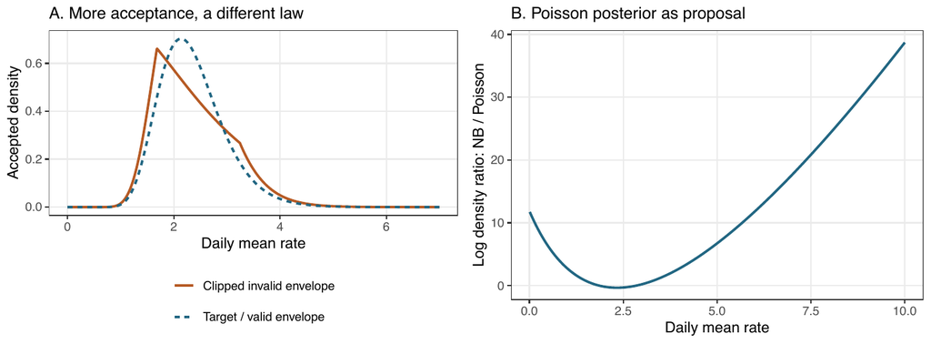

Lecture notes, Section 6.2. The clipped rule distorts the retained density, and the ratio against the Poisson proposal grows in the right tail.

## What a product envelope costs

**Concept.** For $d$ independent coordinates with a common scalar bound $M_1$, the global envelope is $M_1^d$ for joint rejection. Sampling each independent coordinate to acceptance avoids discarding successful coordinates.

**Example.** Use the lecture’s $M_1=1.2$ and compare costs at $d=20$. Compute both costs in scalar proposals to use the same units.

```r
dimension <- 1:30
M1 <- 1.2
joint_cost <- dimension * M1^dimension
separate_cost <- dimension * M1
c(joint_acceptance = M1^-20, joint_scalar_cost = joint_cost[20],
  separate_scalar_cost = separate_cost[20])
```

```
##     joint_acceptance    joint_scalar_cost separate_scalar_cost
##           0.02608405         766.75199849          24.00000000
```

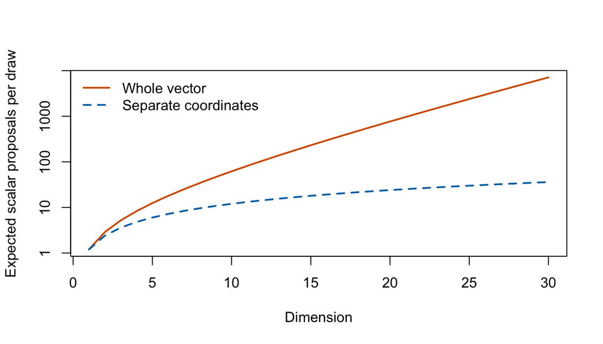

Whole-vector rejection discards all coordinates when the vector fails its acceptance test. The separate cost applies to independent targets.

```r
plot(dimension, joint_cost, type = "l", log = "y", col = "#D55E00",
     lwd = 2, xlab = "Dimension", ylab = "Expected scalar proposals per draw")
lines(dimension, separate_cost, col = "#0072B2", lty = 2, lwd = 2)
legend("topleft", c("Whole vector", "Separate coordinates"), lwd = 2,
       lty = 1:2, col = c("#D55E00", "#0072B2"), bty = "n")
```

# Section 6.3 — Importance Sampling

## Ordinary weights for a rare event

**Concept.** When the target density $\pi$ is normalized, the average of $h(X)\pi(X)/q(X)$ over independent $q$ draws estimates $E_\pi[h(X)]$. The contribution’s standard deviation determines the MCSE.

**Example.** Under a standard Normal target, estimate the chance of exceeding four. A $N(4,1)$ proposal spends about half its draws above four, where the integrand is nonzero.

Generate draws from the shifted Normal and evaluate the density ratio only at exceedances. Compare with the exact Normal tail and calculate the budgets implied by the two methods’ exact variances.

```r
set.seed(63031)
n_rare <- 10000L
x_rare <- rnorm(n_rare, mean = 4)
contribution <- numeric(n_rare)
hit <- x_rare > 4
contribution[hit] <- exp(dnorm(x_rare[hit], log = TRUE) -
                           dnorm(x_rare[hit], mean = 4, log = TRUE))

rare_truth <- pnorm(4, lower.tail = FALSE)
rare_mcse <- sd(contribution) / sqrt(n_rare)
stopifnot(abs(mean(contribution) - rare_truth) < 5 * rare_mcse)
c(exact = rare_truth, estimate = mean(contribution),
  MCSE = rare_mcse, proposal_hits = sum(hit))
```

```
##         exact      estimate          MCSE proposal_hits
##  3.167124e-05  3.167779e-05  6.698538e-07  5.022000e+03
```

```r
rare_variances <- c(direct = rare_truth * (1 - rare_truth),
                    shifted = exp(16) * pnorm(8, lower.tail = FALSE) - rare_truth^2)
ceiling(rare_variances / (.1 * rare_truth)^2)
```

```
##  direct shifted
## 3157339     452
```

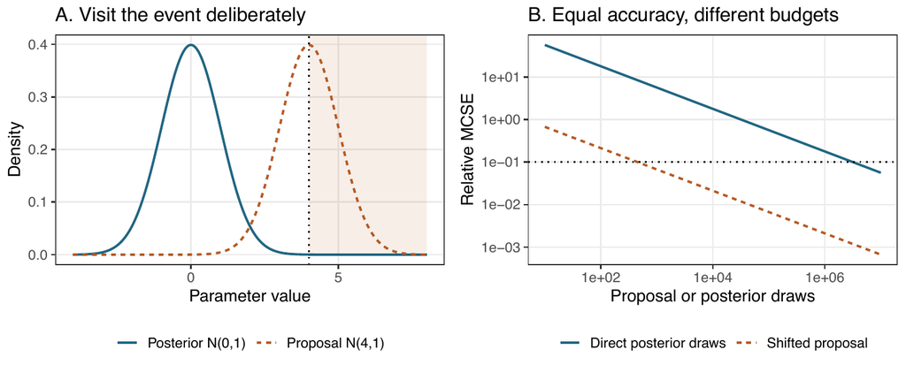

Course figure for Section 6.3. Compare the number of draws needed to reach a relative MCSE of 10%.

A proposal designed for one integral may be unsuitable for other summaries. The calculation above uses the known Normal normalization. A posterior kernel usually needs the ratio of averages below.

## Self-normalized weights for transmission prediction

**Concept.** Posterior weights can be computed up to a common constant. Normalize them to sum to one, and average the prediction using those masses. The MCSE uses the *centered weighted contributions*.

**Example.** Model manual transmission in the 32 `datasets::mtcars` records using standardized weight and horsepower with an intercept. Use independent $N(0,100)$ priors for the three coefficients. At mean horsepower, compare manual-transmission probabilities at 2,000, 3,000, and 4,000 lb and at the sample mean weight.

Use a stable log likelihood and find its penalized mode. Invert the negative log posterior Hessian at the mode and use twice that matrix as the scale of a multivariate $t_5$ proposal. The row of standard Normals and the chi-square draw in the same row form one multivariate Student draw. Subtract the proposal log density from the log kernel, then subtract the largest log weight before exponentiating.

```r
normalize_weights <- function(log_weights) {
  mass <- exp(log_weights - max(log_weights))
  mass / sum(mass)
}

weighted_summary <- function(h, weights) {
  h <- as.matrix(h)
  estimate <- colSums(h * weights)
  centered <- sweep(h, 2, estimate, "-")
  n <- length(weights)
  mcse <- sqrt(n / (n - 1) * colSums((weights * centered)^2))
  rbind(estimate = estimate, MCSE = mcse)
}

cars6 <- datasets::mtcars
standardized <- scale(cars6[c("wt", "hp")])
car_X <- cbind(1, standardized)
car_y <- cars6$am
stopifnot(nrow(car_X) == 32, sum(car_y) == 13)
softplus <- function(x) pmax(x, 0) + log1p(exp(-abs(x)))
negative_log_post <- function(beta) {
  linear <- drop(car_X %*% beta)
  sum(softplus(linear) - car_y * linear) + sum(beta^2) / 200
}
negative_gradient <- function(beta) {
  fitted <- plogis(drop(car_X %*% beta))
  drop(crossprod(car_X, fitted - car_y)) + beta / 100
}
fit <- optim(rep(0, 3), negative_log_post, gr = negative_gradient,
             method = "BFGS", control = list(reltol = 1e-12))
stopifnot(fit$convergence == 0, max(abs(negative_gradient(fit$par))) < 1e-5)
mode_p <- plogis(drop(car_X %*% fit$par))
local_hessian <- crossprod(car_X, car_X * (mode_p * (1 - mode_p))) +
  diag(1 / 100, 3)
local_chol <- chol(solve(local_hessian))

set.seed(5011302)
n_car <- 200000L
df_car <- 5
z_car <- matrix(rnorm(n_car * 3), ncol = 3) *
  sqrt(2) / sqrt(rchisq(n_car, df_car) / df_car)
beta_car <- sweep(z_car %*% local_chol, 2, fit$par, "+")
log_q_car <- -(df_car + 3) / 2 * log1p(rowSums(z_car^2) / (2 * df_car))
log_target_car <- numeric(n_car)
for (first in seq.int(1L, n_car, by = 10000L)) {
  rows <- first:min(first + 9999L, n_car)
  linear <- beta_car[rows, , drop = FALSE] %*% t(car_X)
  log_target_car[rows] <- drop(linear %*% car_y) - rowSums(softplus(linear)) -
    rowSums(beta_car[rows, , drop = FALSE]^2) / 200
}
car_weights <- normalize_weights(log_target_car - log_q_car)
```

For each weight, evaluate every candidate regression at that weight and at sample-mean horsepower. Average the same candidate predictions once with equal masses and once with importance masses. The omitted constant in `log_q_car` cancels when normalizing.

```r
profiles <- c(2, 3, 4, mean(cars6$wt))
z_wt <- (profiles - attr(standardized, "scaled:center")[["wt"]]) /
  attr(standardized, "scaled:scale")[["wt"]]
manual <- plogis(outer(beta_car[, 2], z_wt) + beta_car[, 1])
car_results <- weighted_summary(manual, car_weights)
stopifnot(abs(sum(car_weights) - 1) < 1e-12,
          abs(car_results["estimate", 4] - .1450) < .003)
knitr::kable(data.frame(weight_lb = round(1000 * profiles),
                        equal_mass = colMeans(manual),
                        posterior = car_results["estimate", ],
                        MCSE = car_results["MCSE", ]), digits = 4)
```

| weight_lb | equal_mass | posterior | MCSE |
| --- | --- | --- | --- |
| 2000 | 0.9320 | 0.9987 | 0e+00 |
| 3000 | 0.4897 | 0.4980 | 6e-04 |
| 4000 | 0.0648 | 0.0012 | 0e+00 |
| 3217 | 0.2375 | 0.1454 | 3e-04 |

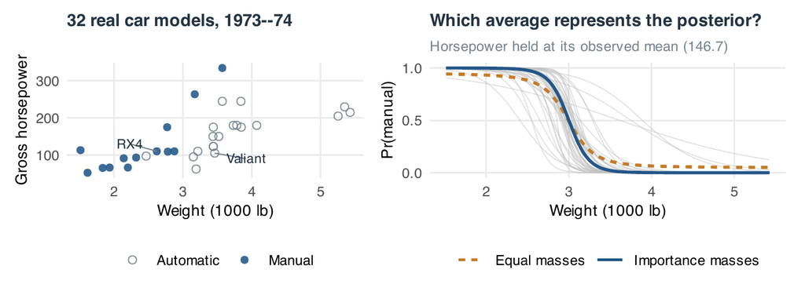

Lecture notes, Section 6.3. The weighted and equal-mass curves average the same candidate regressions at mean horsepower.

The weighted curve describes the fitted probability for a specified profile in this observational model. Its MCSE measures the precision of the computed posterior average.

## Weighted joint records for Eight Schools

**Concept.** If a proposal uses the target’s exact conditionals, only the approximate marginal needs a weight correction. Each weight belongs to a complete joint record.

**Example.** Use the model in Section 6.1. School A’s estimated effect is 28 points with SE 15. The estimate at G is 18 with SE 10. Estimate $\Pr(\theta_G>\theta_A\mid\mathbf y)$ together with $\Pr(\tau>10\mid\mathbf y)$ and the mean shrinkage weight $225/(225+\tau^2)$ for A.

Calculate the mode and curvature on the $z=\log\tau$ scale. Use the notes’ narrow and broad $t_5$ proposals with scale multipliers $0.5$ and $1.5$. At each proposed scale, draw one $\eta$ and use it for all eight school effects. The Normal conditional densities cancel from the ratio, leaving the log-scale kernel minus the log proposal.

```r
z_mode <- mode_fit$maximum
step <- 1e-4
curvature <- -(log_scale_kernel(z_mode + step) -
                 2 * log_scale_kernel(z_mode) +
                 log_scale_kernel(z_mode - step)) / step^2
local_scale <- 1 / sqrt(curvature)

sample_school_records <- function(multiplier, n) {
  proposal_scale <- multiplier * local_scale
  z <- z_mode + proposal_scale * rt(n, df = 5)
  log_q <- dt((z - z_mode) / proposal_scale, df = 5, log = TRUE) -
    log(proposal_scale)
  tau <- exp(z)
  gaussian <- school_means_conditional(tau, school_y, school_s2, 0, 400)
  eta <- rnorm(n, gaussian$m, sqrt(gaussian$v))
  conditional_mean <- sweep(gaussian$w, 2, school_y, "*") +
    (1 - gaussian$w) * eta
  theta <- matrix(rnorm(length(conditional_mean), conditional_mean,
                        sqrt(gaussian$d)), nrow = n,
                  dimnames = list(NULL, names(school_y)))
  log_weights <- log_scale_kernel(z) - log_q
  list(z = z, tau = tau, eta = eta, theta = theta, log_weights = log_weights,
       weights = normalize_weights(log_weights))
}

set.seed(63051)
school_samples <- lapply(c(Narrow = .5, Broad = 1.5), sample_school_records,
                         n = 2000L)
c(log_scale_mode = z_mode, curvature_scale = local_scale)
```

```
##  log_scale_mode curvature_scale
##       2.0169055       0.2483556
```

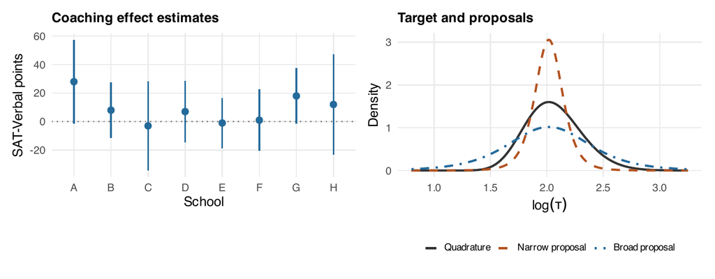

Lecture notes, Section 6.3. The bars are effect estimates plus or minus 1.96 standard errors. The proposals approximate the marginal posterior of log tau.

For the quadrature benchmark on the effect comparison, integrate out the shared center analytically at each scale. The contrast variance is $d_G+d_A+(w_G-w_A)^2v_\tau$. Evaluate the Normal exceedance probability using that variance, then integrate it over $\tau$. The weighted sample instead averages the indicator from each complete record.

```r
pooling_A <- function(tau) school_s2[["A"]] / (school_s2[["A"]] + tau^2)
contrast_probability <- function(tau, first, second, threshold = 0) {
  g <- school_means_conditional(tau, school_y, school_s2, 0, 400)
  cols <- match(c(first, second), names(school_y))
  a <- cols[1]
  b <- cols[2]
  mean_diff <- g$m_school[, a] - g$m_school[, b]
  var_diff <- g$d[, a] + g$d[, b] + (g$w[, a] - g$w[, b])^2 * g$v
  pnorm(threshold, mean_diff, sqrt(var_diff), lower.tail = FALSE)
}

school_truth <- c(tail = tail_reference,
                   pooling = scale_integral(pooling_A) / scale_norm,
                   comparison = scale_integral(function(t) {
                     contrast_probability(t, "G", "A")
                   }) / scale_norm)
school_summaries <- lapply(school_samples, function(x) {
  h <- cbind(tail = x$tau > 10, pooling = pooling_A(x$tau),
             comparison = x$theta[, "G"] > x$theta[, "A"])
  weighted_summary(h, x$weights)
})

table_school <- data.frame(
  summary = c("Pr(tau > 10)", "Mean pooling weight for A", "Pr(effect G > effect A)"),
  quadrature = unname(school_truth),
  narrow = unname(school_summaries$Narrow["estimate", ]),
  narrow_MCSE = unname(school_summaries$Narrow["MCSE", ]),
  broad = unname(school_summaries$Broad["estimate", ]),
  broad_MCSE = unname(school_summaries$Broad["MCSE", ])
)
stopifnot(max(abs(school_truth - c(.169870, .7725, .4785))) < 5e-5,
          all(vapply(school_summaries, function(result) {
            all(abs(result["estimate", ] - school_truth) < 4 * result["MCSE", ])
          }, logical(1))))
weight_ess <- function(weights) 1 / sum(weights^2)
knitr::kable(table_school, digits = 4)
```

| summary | quadrature | narrow | narrow_MCSE | broad | broad_MCSE |
| --- | --- | --- | --- | --- | --- |
| Pr(tau > 10) | 0.1699 | 0.1557 | 0.0187 | 0.1772 | 0.0085 |
| Mean pooling weight for A | 0.7725 | 0.7718 | 0.0044 | 0.7699 | 0.0018 |
| Pr(effect G > effect A) | 0.4785 | 0.4667 | 0.0154 | 0.4878 | 0.0127 |

```r
vapply(school_samples, function(x) weight_ess(x$weights), numeric(1))
```

```
##   Narrow    Broad
## 1041.419 1557.574
```

A weighted empirical CDF sums the masses of draws at or below each threshold. To find its quantiles, sort the records by the value of interest and invert the cumulative masses by first crossing, as in Section 6.1.

```r
weighted_quantile <- function(x, weights, probs) {
  ordered <- order(x)
  cumulative <- cumsum(weights[ordered])
  cumulative[length(cumulative)] <- 1
  vapply(probs, function(p) x[ordered[which(cumulative >= p)[1]]], numeric(1))
}
broad <- school_samples$Broad
cdf_at_10 <- c(equal_masses = mean(broad$tau <= 10),
               weighted = sum(broad$weights[broad$tau <= 10]),
               quadrature = 1 - tail_reference)
interval_tau <- weighted_quantile(broad$tau, broad$weights, c(.025, .975))
cdf_at_10
```

```
## equal_masses     weighted   quadrature
##    0.7500000    0.8227547    0.8301304
```

```r
setNames(interval_tau, c("2.5%", "97.5%"))
```

```
##      2.5%     97.5%
##  5.019607 13.562695
```

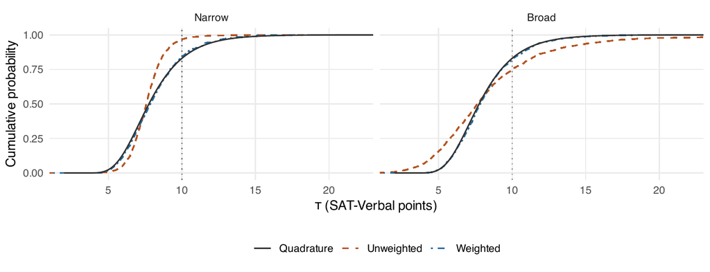

Lecture notes, Section 6.3. Weighting corrects the proposal CDF. The vertical line marks the tail-probability threshold.

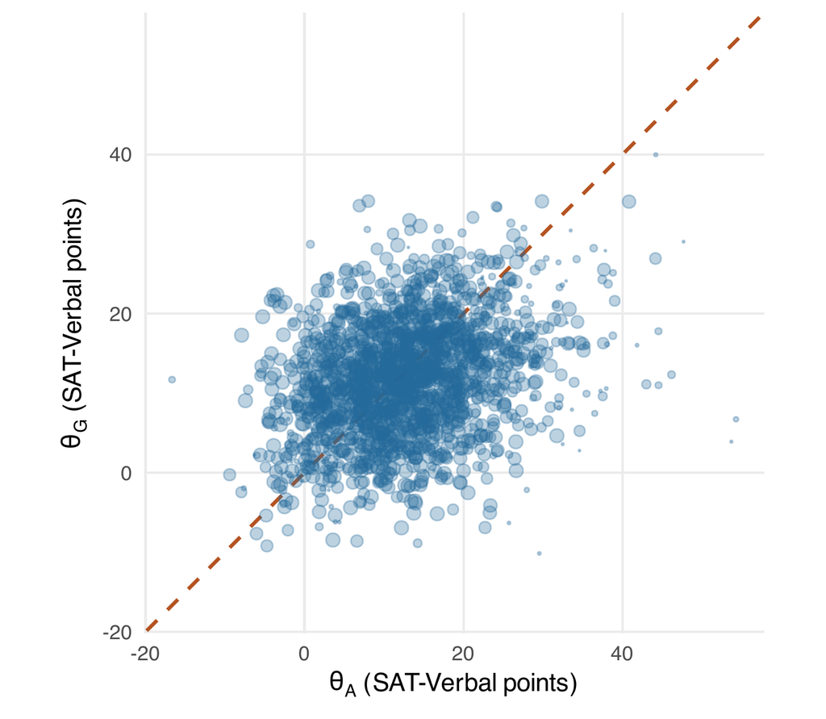

Lecture notes, Section 6.3. Dot area represents importance mass. The event G > A lies above the diagonal.

The broad proposal lowers the MCSE of the scale summaries in this run. The gain is smaller for the comparison of effects, which also varies with the conditional Normal draws at each scale.

## Light tails and missed modes

**Concept.** Accuracy depends on the contributions for the particular estimand. Self-normalization uses weights from the entire proposal sample. The weights observed in one run may provide little information about regions the proposal missed.

**Example.** Estimate the Cauchy probability of $[-1,1]$ using a standard Normal proposal. For ordinary importance sampling, the squared weights matter only on $[-1,1]$. For the self-normalized estimator, the squared centered indicator is $1/4$ both inside and outside that interval.

Integrate the two second-moment expressions on successively wider intervals. The ordinary contribution’s variance is the first second moment minus $1/4$. The SNIS asymptotic variance integral keeps growing because its integrand is proportional to $e^{x^2/2}/(1+x^2)^2$ in the tails.

```r
squared_weight_density <- function(x) {
  exp(2 * dcauchy(x, log = TRUE) - dnorm(x, log = TRUE))
}
radii <- seq(1, 8, by = .25)
ordinary_var <- quad(squared_weight_density, -1, 1) - .25
truncated_var <- vapply(radii, function(r) {
  quad(squared_weight_density, -r, r) / 4
}, numeric(1))
knitr::kable(data.frame(radius = radii[c(1, 9, 21, 29)],
                        ordinary = ordinary_var,
                        SNIS_truncated = truncated_var[c(1, 9, 21, 29)]))
```

| radius | ordinary | SNIS_truncated |
| --- | --- | --- |
| 1 | 0.1178107 | 9.195270e-02 |
| 3 | 0.1178107 | 1.931441e-01 |
| 6 | 0.1178107 | 1.188997e+03 |
| 8 | 0.1178107 | 3.224474e+08 |

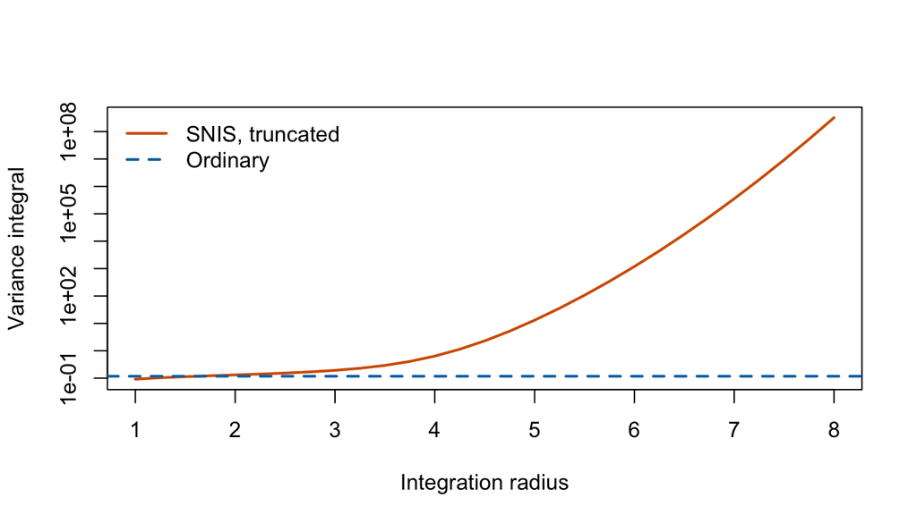

The ordinary variance is finite. The truncated SNIS variance integral grows as more of the tails enter the calculation.

```r
plot(radii, truncated_var, type = "l", log = "y", lwd = 2,
     col = "#D55E00", xlab = "Integration radius", ylab = "Variance integral")
abline(h = ordinary_var, lty = 2, col = "#0072B2", lwd = 2)
legend("topleft", c("SNIS, truncated", "Ordinary"), lty = 1:2,
       col = c("#D55E00", "#0072B2"), lwd = 2, bty = "n")
```

**Example.** Now give the target two equally weighted Normal components centered at $-8$ and $8$, each with unit variance. Compare a proposal centered at $-8$ with a proposal covering both modes. For the left proposal, $\pi/q=(1+\exp(16x))/2$. Evaluate its logarithm using `softplus()` and report the observed right-mode visits, weight ESS, and mean.

```r
set.seed(63061)
n_mode <- 2000L
left_sample <- rnorm(n_mode, -8)
left_weights <- normalize_weights(softplus(16 * left_sample) - log(2))
balanced_sample <- rnorm(n_mode, ifelse(runif(n_mode) < .5, -8, 8))
mode_results <- rbind(
  left = weighted_summary(left_sample, left_weights)[, 1],
  balanced = weighted_summary(balanced_sample, rep(1 / n_mode, n_mode))[, 1]
)
knitr::kable(cbind(mode_results, weight_ESS = c(weight_ess(left_weights), n_mode),
                   right_visits = c(sum(left_sample > 0), sum(balanced_sample > 0))),
             digits = 4)
```

|  | estimate | MCSE | weight_ESS | right_visits |
| --- | --- | --- | --- | --- |
| left | -8.0357 | 0.0228 | 2000 | 0 |
| balanced | 0.0387 | 0.1802 | 2000 | 1010 |

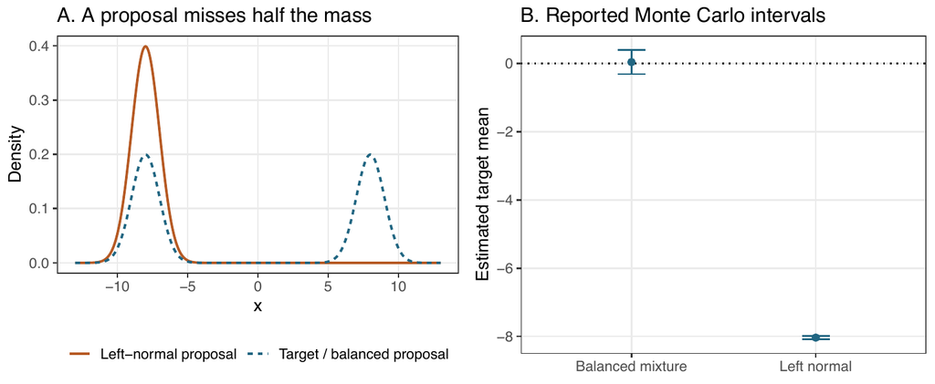

Course figure for Section 6.3. Even a proposal positive on the whole real line can miss an important mode at a finite budget.

In the left-proposal run, nearly equal weights make the observed ESS large. The estimate is close to the left mode, while the true mean is zero. A small estimated MCSE cannot detect missing contributions.

## Reweighting and resampling school records

**Concept.** If the likelihood stays fixed, changing a prior multiplies the old weights by the prior ratio. Resampling draws from the resulting weighted empirical distribution and adds conditional Monte Carlo error.

**Example.** Lower the inverse-gamma scale from 200 to 50 to favor more pooling. Compare $\Pr(\theta_A-\theta_E>10\mid\mathbf y)$ under both priors. Then resample under the revised weights and compare the resampled fraction with the fraction calculated directly from those weights.

Keep the original joint records. Add $\log p_{50}(\tau)-\log p_{200}(\tau)$ to their log weights. Calculate the probability using both the sampled indicator and the conditional Normal exceedance probability. The latter averages out the variation due to drawing the effects at each scale.

```r
set.seed(63073)
sensitivity <- sample_school_records(1.5, 4000L)
revised <- normalize_weights(sensitivity$log_weights +
  log_scale_prior(sensitivity$tau, 50) - log_scale_prior(sensitivity$tau, 200))
difference <- sensitivity$theta[, "A"] - sensitivity$theta[, "E"]
h_AE <- function(tau) contrast_probability(tau, "A", "E", threshold = 10)
h_compare <- cbind(indicator = difference > 10,
                   conditional = h_AE(sensitivity$tau))
priors <- list(baseline = sensitivity$weights, revised = revised)
reference_AE <- vapply(c(200, 50), function(b) {
  scale_integral(h_AE, b = b) / scale_integral(ones, b = b)
}, numeric(1))
sensitivity_table <- t(vapply(priors, function(w) {
  as.vector(weighted_summary(h_compare, w))
}, numeric(4)))
colnames(sensitivity_table) <- c("Indicator", "Indicator MCSE",
                                 "Conditional", "Conditional MCSE")
knitr::kable(cbind(quadrature = reference_AE, sensitivity_table,
                   weight_ESS = vapply(priors, weight_ess, numeric(1))), digits = 4)
```

|  | quadrature | Indicator | Indicator MCSE | Conditional | Conditional MCSE | weight_ESS |
| --- | --- | --- | --- | --- | --- | --- |
| baseline | 0.4132 | 0.4196 | 0.0088 | 0.4146 | 0.0018 | 3138.6899 |
| revised | 0.1326 | 0.1420 | 0.0098 | 0.1326 | 0.0029 | 869.9147 |

```r
set.seed(63074)
resampled <- sample.int(length(revised), 4000L, replace = TRUE, prob = revised)
weighted_event <- sensitivity_table["revised", "Indicator"]
c(weighted = unname(weighted_event), resampled = mean(difference[resampled] > 10),
  extra_MCSE = sqrt(weighted_event * (1 - weighted_event) / length(resampled)))
```

```
##    weighted   resampled  extra_MCSE
## 0.142030783 0.135250000 0.005519466
```

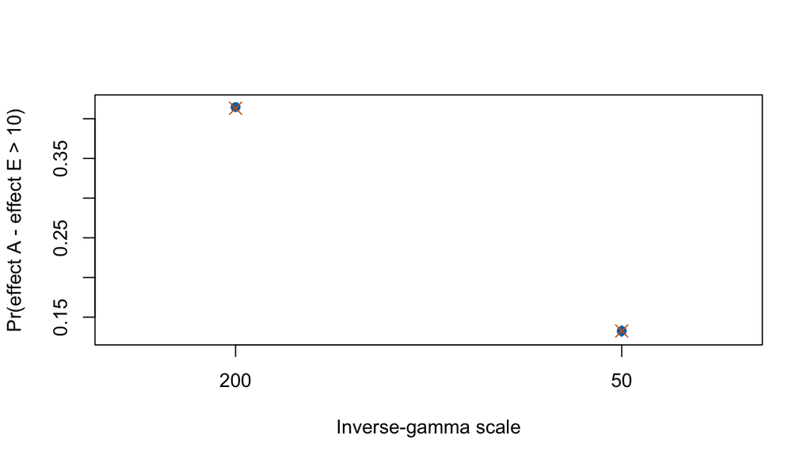

Conditional averaging integrates out the school effects at each scale. The bars show two MCSEs around the weighted estimate, and the crosses mark quadrature benchmarks.

```r
centers <- sensitivity_table[, "Conditional"]
half_width <- 2 * sensitivity_table[, "Conditional MCSE"]
plot(1:2, centers, ylim = range(centers - half_width, centers + half_width,
                               reference_AE), xlim = c(.7, 2.3),
     xaxt = "n", xlab = "Inverse-gamma scale", ylab = "Pr(effect A - effect E > 10)",
     pch = 19, col = "#0072B2")
axis(1, 1:2, c(200, 50))
segments(1:2, centers - half_width, 1:2, centers + half_width,
         col = "#0072B2", lwd = 2)
points(1:2, reference_AE, pch = 4, col = "#D55E00", cex = 1.4)
```

Increasing the resample size reduces the extra MCSE shown above. It does not improve the original weighted approximation. For a probability calculation, the weighted fraction is available directly.

## Sequential weights under repeated mismatch

**Concept.** When a proposed record is built one coordinate at a time, its weight multiplies by a new density ratio at each step. Modest mismatch in each coordinate can add up.

**Example.** Propose independent standard Normal coordinates. The target shifts each coordinate’s mean to $0.4$, keeping its variance one. For a record of length $d$, the limiting weight ESS fraction is $\exp(-0.4^2d)$.

Draw one new coordinate per record at each step and add its log ratio $0.4x-0.4^2/2$ to the record’s log weight. Renormalize for the ESS calculation and compare the observed fraction with the fixed-dimension limit.

```r
set.seed(63076)
n_path <- 20000L
shift <- .4
steps <- 1:20
path_log_weights <- numeric(n_path)
ess_fraction <- numeric(length(steps))
for (i in steps) {
  next_coordinate <- rnorm(n_path)
  path_log_weights <- path_log_weights + shift * next_coordinate - shift^2 / 2
  ess_fraction[i] <- weight_ess(normalize_weights(path_log_weights)) / n_path
}
limiting_fraction <- exp(-shift^2 * steps)
show <- c(1, 5, 10, 20)
knitr::kable(data.frame(d = steps[show], observed = ess_fraction[show],
                        limit = limiting_fraction[show]), digits = 4)
```

| d | observed | limit |
| --- | --- | --- |
| 1 | 0.8493 | 0.8521 |
| 5 | 0.4498 | 0.4493 |
| 10 | 0.2078 | 0.2019 |
| 20 | 0.0563 | 0.0408 |

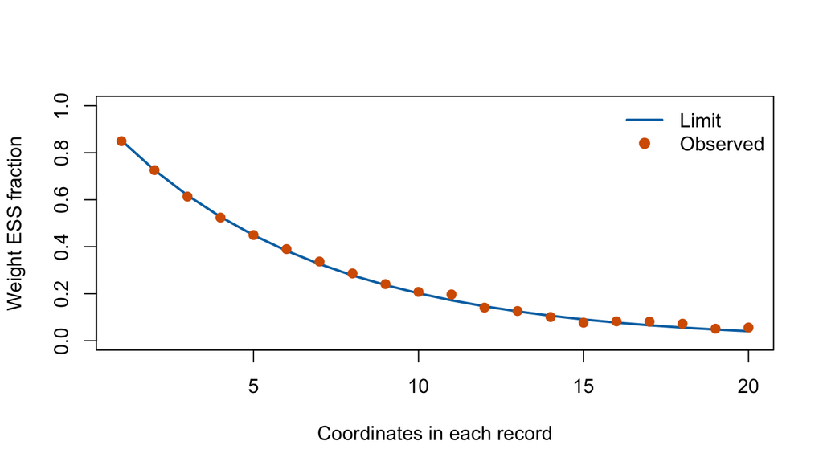

A small proposal shift in each coordinate accumulates as the record grows.

```r
plot(steps, limiting_fraction, type = "l", lwd = 2, col = "#0072B2",
     xlab = "Coordinates in each record", ylab = "Weight ESS fraction",
     ylim = c(0, 1))
points(steps, ess_fraction, pch = 19, col = "#D55E00")
legend("topright", c("Limit", "Observed"), lty = c(1, NA), pch = c(NA, 19),
       col = c("#0072B2", "#D55E00"), lwd = 2, bty = "n")
```

## Annealed importance sampling

**Concept.** Annealed importance sampling changes the target along a sequence of distributions on the same space. Evaluate each weight increment before moving the record with a transition that preserves the new intermediate target.

**Example.** For the 12 daily counts, let a Poisson likelihood replace the negative-binomial likelihood used in Section 6.2. Use the same $\operatorname{Gamma}(2,1)$ prior. Under a likelihood power $\beta$, the intermediate target is exactly $\operatorname{Gamma}(2+28\beta,1+12\beta)$. That gives an exact invariant move, so this example can isolate the order of weighting and moving.

Start each record with one prior rate. At each step, add the power increment times the log likelihood at the current rate, then refresh the rate from the new intermediate target. For one step, the raw weights are just the prior importance weights. Compare the evidence and weight ESS with a five-step schedule and with the exact Gamma–Poisson evidence. For the log evidence, divide the MCSE of the mean weight by the mean weight, using the delta method.

```r
count_log_poisson <- function(lambda) {
  total * log(lambda) - length(counts) * lambda - sum(lfactorial(counts))
}
anneal <- function(powers, n) {
  lambda <- rgamma(n, 2, rate = 1)
  log_weights <- numeric(n)
  for (i in seq_len(length(powers) - 1L)) {
    next_power <- powers[i + 1L]
    log_weights <- log_weights +
      (next_power - powers[i]) * count_log_poisson(lambda)
    lambda <- rgamma(n, 2 + next_power * total,
                      rate = 1 + next_power * length(counts))
  }
  log_shift <- max(log_weights)
  shifted <- exp(log_weights - log_shift)
  c(log_evidence = log_shift + log(mean(shifted)),
    log_evidence_MCSE = sd(shifted) / (sqrt(n) * mean(shifted)),
    weight_ESS = weight_ess(normalize_weights(log_weights)))
}
set.seed(63075)
anneal_results <- rbind(one_step = anneal(c(0, 1), 10000L),
                        five_steps = anneal(seq(0, 1, by = .2), 10000L))
poisson_exact <- lgamma(2 + total) - lgamma(2) -
  (2 + total) * log(1 + length(counts)) - sum(lfactorial(counts))
knitr::kable(cbind(anneal_results, exact_log_evidence = poisson_exact), digits = 4)
```

|  | log_evidence | log_evidence_MCSE | weight_ESS | exact_log_evidence |
| --- | --- | --- | --- | --- |
| one_step | -26.0353 | 0.0139 | 3411.695 | -26.0533 |
| five_steps | -26.0487 | 0.0094 | 5332.057 | -26.0533 |

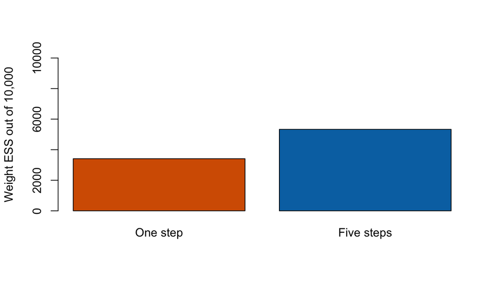

In this conjugate illustration, an exact refresh at each intermediate target reduces the concentration of the evidence weights.

```r
barplot(anneal_results[, "weight_ESS"], names.arg = c("One step", "Five steps"),
        col = c("#D55E00", "#0072B2"), ylim = c(0, 10000),
        ylab = "Weight ESS out of 10,000")
```

The schedules use the same number of independent paths and different numbers of intermediate draws. ESS alone does not account for that cost. This conjugate model is a check on the algorithm; in the logistic model the intermediate laws typically require transitions that preserve the tempered target.

**Try next.** In Section 6.1, refine the grid and then double the inversion sample size. Compare their effects on CDF error and the MCSE. In Section 6.2, simulate with the valid loose bound and check both its acceptance rate and posterior mean. In Section 6.3, use the narrow proposal to reweight the school prior and compare its MCSE against the broad proposal for the same contrast.

R 4.6.0 · BayesComp 0.1.0